# Non Parametric Statistic : Estimation de densité avec les données geyser

NIANG Mohamed

6 janvier 2020

```r
library(MASS)
```

# 1 Description

La base de données geyser de la librairie MASS contient des données d’éruption (temps d’attente et durée) de l’Old Faithful geyser du Yellowstone National Park.

# 2 Histogramme

La fonction hist permet d’obtenir un histogramme de la distribution des observations.

## 2.1 Histogramme en fréquence puis en proba des observations

```r
gdata <- geyser
waiting <- gdata[,1]
duration <- gdata[,2]
```

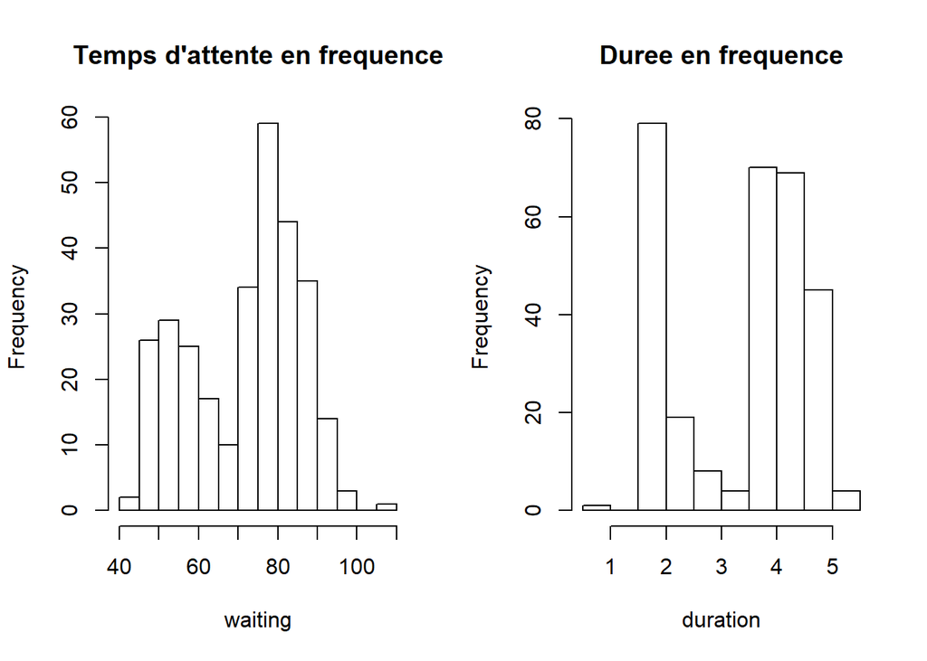

```r
par(mfrow = c(1, 2))
hist(waiting, proba = F, main = "Temps d'attente en frequence")
hist(duration, proba = F, main = "Duree en frequence")
```

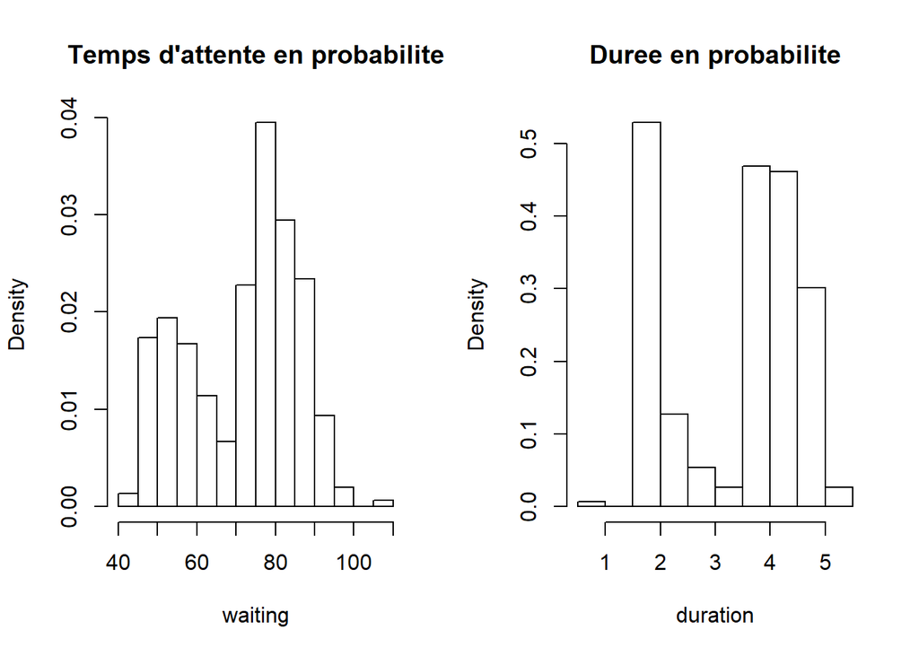

```r
par(mfrow = c(1, 2))
hist(waiting, proba = T, main = "Temps d'attente en probabilite")
hist(duration, proba = T, main = "Duree en probabilite")
```

## 2.2 Variation de l’argument breaks et constat

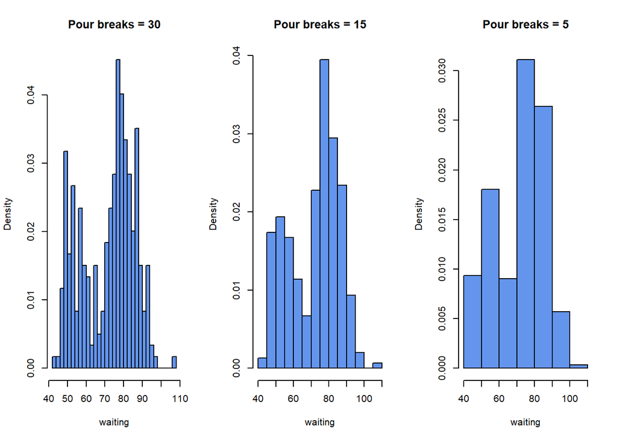

```r
par(mfrow = c(1,3))
hist(waiting, col = "cornflowerblue", proba = T, breaks = 30, main = "Pour breaks = 30")
hist(waiting, col = "cornflowerblue", proba = T, breaks = 15, main = "Pour breaks = 15")
hist(waiting, col = "cornflowerblue", proba = T, breaks = 5, main = "Pour breaks = 5")
```

**Commentaires :** Une grande breaks entraine une mauvaise estimation et une petite beaks fait perdre de l’informations. Ainsi pour avoir une bonne estimation, il faut prendre le juste milieu.

## 2.3 Représentation unidimensionnelle des observations

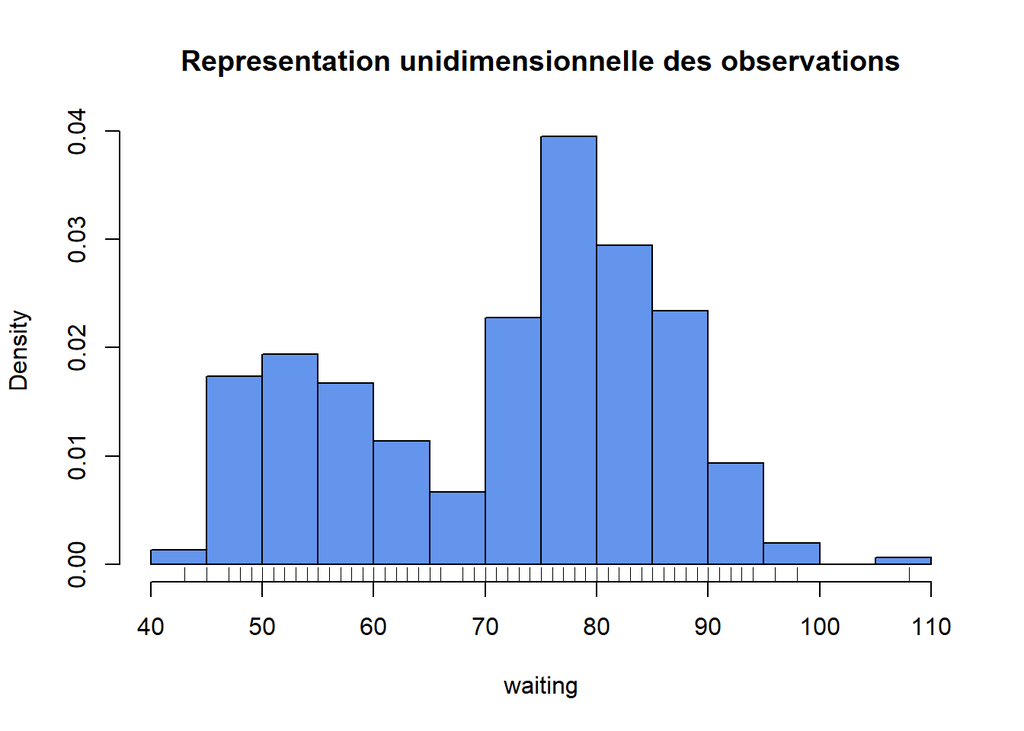

```r
hist(waiting, col = "cornflowerblue", proba = T, breaks = 10, main = "Representation unidimensionnelle des observations")
rug(waiting)
```

## 2.4 Histogramme et truehist

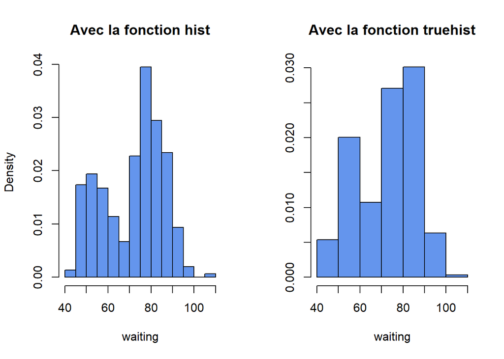

```r
par(mfrow= c(1,2))
hist(waiting, col = "cornflowerblue", proba = T, main = "Avec la fonction hist")
truehist(waiting, col = "cornflowerblue", main = "Avec la fonction truehist")
```

**Commentaires :** La différence se trouve sur le nombre de barre utilisée et la hauteur des barres.

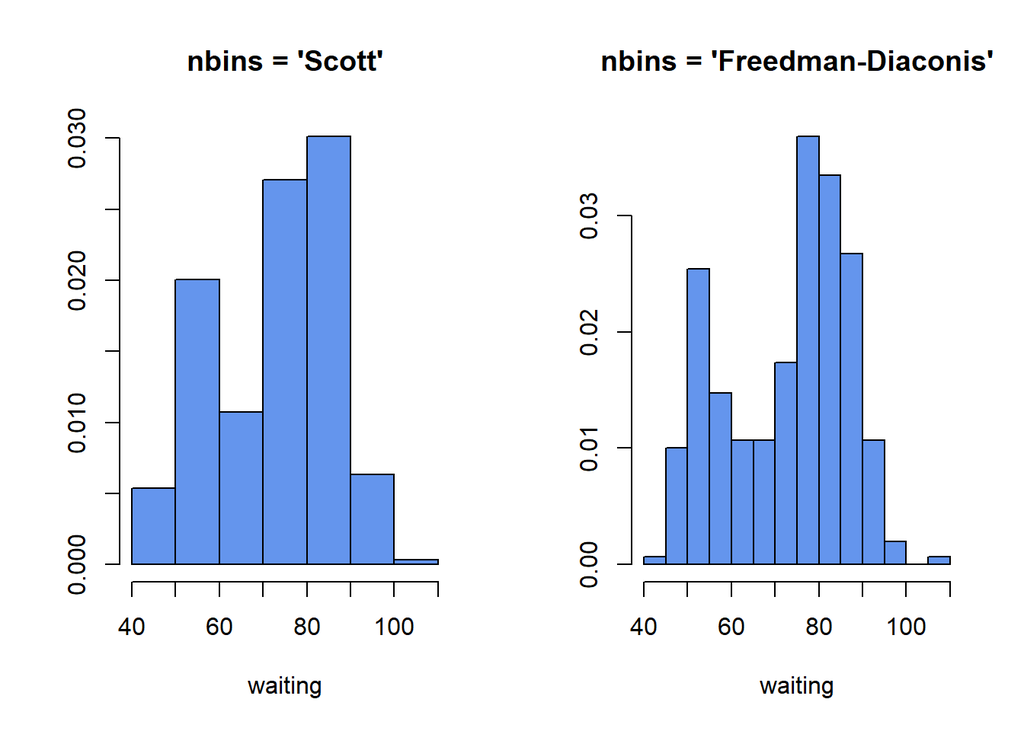

```r
# Differente option proposee par la fonction truehist
par(mfrow= c(1,2))
truehist(waiting, col = "cornflowerblue", main = "nbins = 'Scott'")
truehist(waiting, col = "cornflowerblue", nbins = 'Freedman-Diaconis', main = "nbins = 'Freedman-Diaconis'")
```

# 3 Estimateur à noyau en dimension

## 3.1 Observation de la structure du density

```r
dens <- density(waiting)
dens$n
```

```
## [1] 299
```

```r
length(dens$x)
```

```
## [1] 512
```

**Commentaires :** A partir de 299 individus, la fonction density donne 512 points qui ont une abscisse et une ordonnée, l’ordonnée étant une densité.

## 3.2 Courbe de l’estimateur à noyau

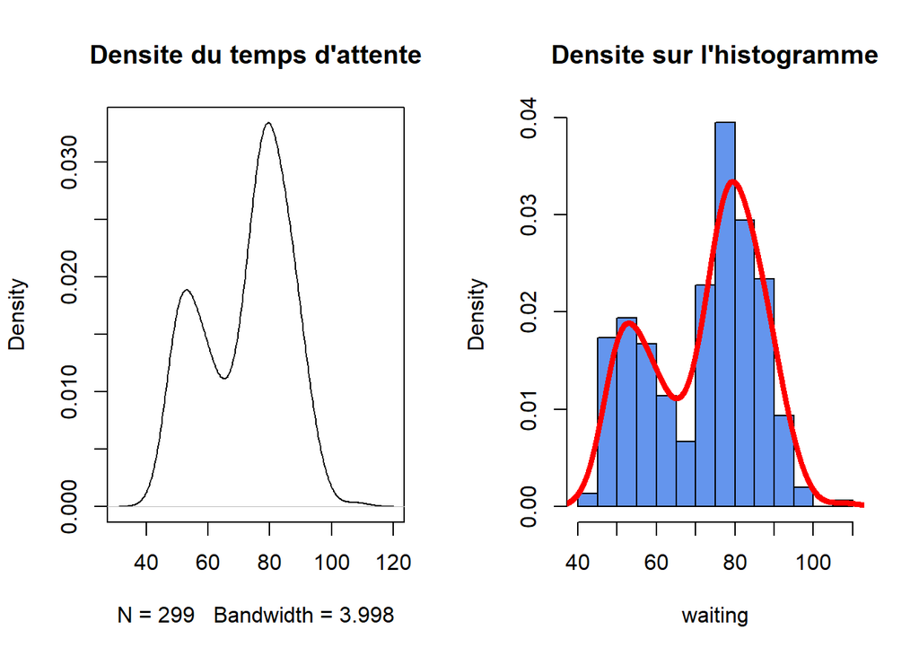

```r
par(mfrow = c(1,2))
plot(dens, main = "Densite du temps d'attente")
hist(waiting, col = "cornflowerblue", proba = T, breaks = 10, main = "Densite sur l'histogramme")
lines(dens, col = "red", lwd = 4)
```

## 3.3 Variation du noyau avec la fonction kernel

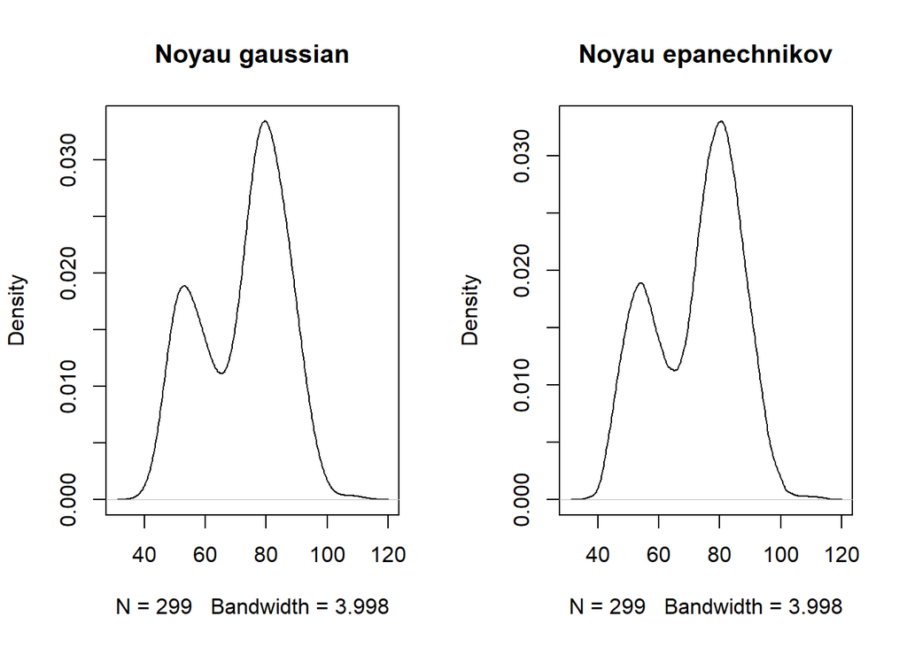

```r
par(mfrow = c(1,2))
plot(density(waiting, kernel = "gaussian"), main = "Noyau gaussian")
plot(density(waiting, kernel = "epanechnikov"), main = "Noyau epanechnikov")
```

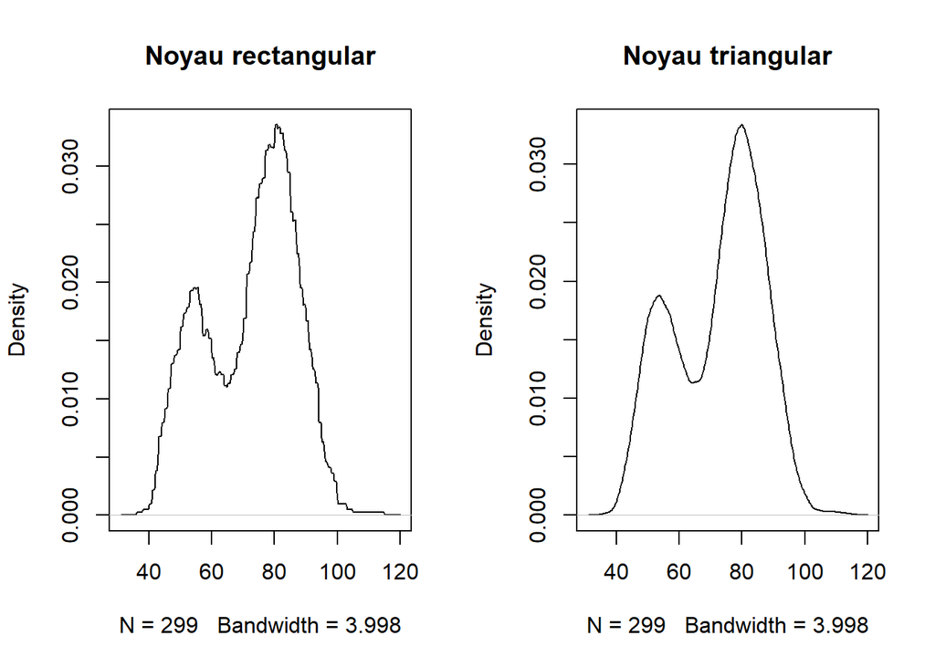

```r
par(mfrow = c(1,2))
plot(density(waiting, kernel = "rectangular"), main = "Noyau rectangular")
plot(density(waiting, kernel = "triangular"), main = "Noyau triangular")
```

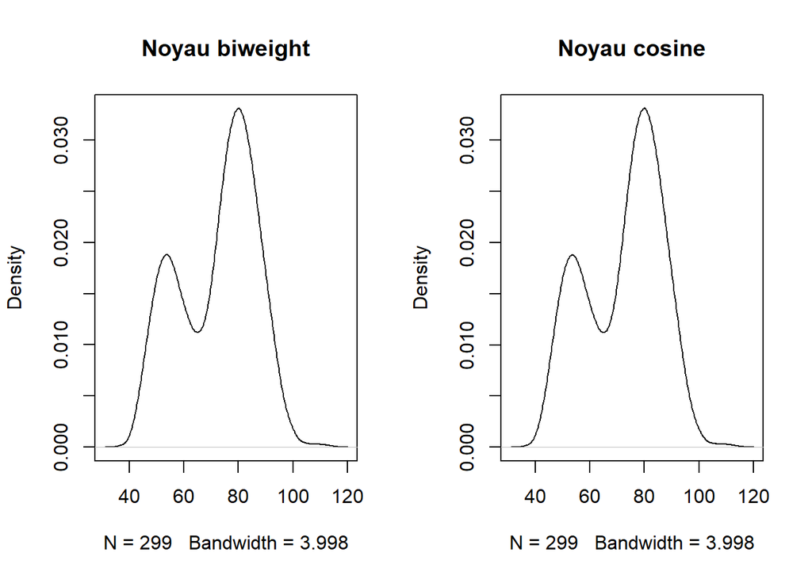

```r
par(mfrow = c(1,2))
plot(density(waiting, kernel = "biweight"), main = "Noyau biweight")
plot(density(waiting, kernel = "cosine"), main = "Noyau cosine")
```

**Commentaires :** Il n’y a pas de différence significative sur la desnité estimée en remplacant le noyau.

## 3.4 Variation du paramètre de fenetre

```r
dens_2 <- density(waiting, bw = 2)
dens_3 <- density(waiting, bw = 3)
dens_4 <- density(waiting, bw = 4)
dens_5 <- density(waiting, bw = 5)
dens_10 <- density(waiting, bw = 10)
```

```r
x_mini <- min(dens_2$x, dens_3$x, dens_4$x, dens_5$x, dens_10$x)
x_maxi <- max(dens_2$x, dens_3$x, dens_4$x, dens_5$x, dens_10$x)
xlimi = c(x_mini, x_maxi)
y_mini <- min(dens_2$y, dens_3$y, dens_4$y, dens_5$y, dens_10$y)
y_maxi <- max(dens_2$y, dens_3$y, dens_4$y, dens_5$y, dens_10$y)
ylimi = c(y_mini, y_maxi)
```

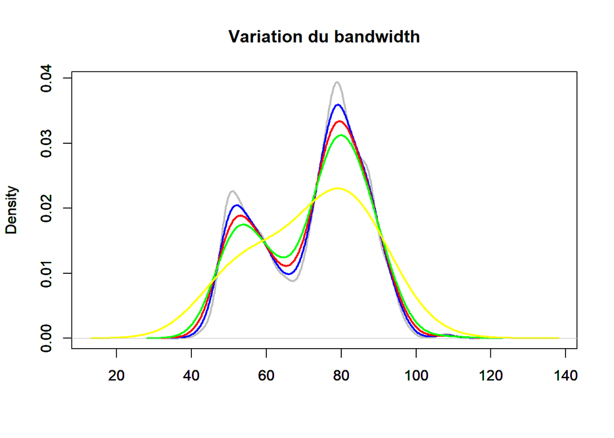

```r
plot(dens_2, xlim = xlimi, ylim = ylimi, main = "Variation du bandwidth", xlab = "", col = "gray", lwd = 2)
par(new=T)
plot(dens_3, xlim = xlimi, ylim = ylimi, main = "", xlab = "", col = "blue", lwd = 2)
par(new=T)
plot(dens_4, xlim = xlimi, ylim = ylimi, main = "", xlab = "", col = "red", lwd = 2)
par(new=T)
plot(dens_5, xlim = xlimi, ylim = ylimi, main = "", xlab = "", col = "green", lwd = 2)
par(new=T)
plot(dens_10, xlim = xlimi, ylim = ylimi, main = "", xlab = "", col = "yellow", lwd = 2)
```

**Commentaires :** Une grande bandwidth entraine de petite variation.

# 4 Validation croisée

## 4.1 L’expression du risque MISE d’un estimateur à noyau

Le risque MISE est défini sous la forme suivante :

$$\mathbb{E}_f||\hat{f}_{n,h}-f||^2_2$$

avec

$$\hat{f}_{n,h}(x) = \frac{1}{nh}\sum_{i=1}^nK(\frac{X_i-x}{h})$$

Ainsi

$$MISE(h)=J(h) = \mathbb{E}_f(\int\hat{f}_{n,h}^2(x)dx)-2\mathbb{E}_f(\int f(x)\hat{f}_{n,h}(x)dx)+cste$$

L’expression de l’estimateur obtenu par validation croisée :

$$\mathbb{E}_f(\int\hat{f}_{n,h}^2(x)dx)$$

Et peut etre estimée par :

$$\int\hat{f}_{n,h}^2(x)dx$$

L’espérance étant linéaire, ce qui entraine :

$$\int f(x)\mathbb{E}_f(\hat{f}_{n,h}(x))dx$$

Ainsi, on a :

$$\mathbb{E}_f(\hat{f}_{n,h}(x)) = \frac{1}{h}\int K(\frac{u-x}{h})f(u)du$$

Ce qui donne :

$$\mathbb{E}_f(\hat{f}_{n,h}(x)) = \frac{1}{n(n-1)h}\sum_i\sum_{j\neq i}K(\frac{X_i-X_j}{h})$$

D’où :

$$\hat{J}(h) = \int\hat{f}_{n,h}^2(x)dx-\frac{2}{n(n-1)h}\sum_i\sum_{j\neq i}K(\frac{X_i-X_j}{h})$$

Par validation croisée, on obtient :

$$\hat{J}_{n,h}(h) = \frac{1}{V}\sum_{v=1}^V(\int(\hat{f}_{n,h}^v)^2(x)dx-\frac{2}{|C_v|(|C_v|-1)h}\sum_{i,j\in C_v,j\neq i}K(\frac{X_i-X_j}{h}))$$

## 4.2 Démonstration

On a :

$$\hat{f}^{C_v}_{n,h}(X_i) = \frac{1}{|C_v|h}\sum_{j\in C_v}K(\frac{X_j-X_i}{h})$$

En séparant les i égaux à j de ceux qui sont différents, on a :

$$\sum_{i\in C_v}\hat{f}^{C_v}_{n,h}(X_i)=\frac{1}{|C_v|h}\sum_{i,j\in C_v,i\neq j}K(\frac{X_j-X_i}{h})+\frac{1}{|C_v|h}\sum_{i\in C_v}K(0)$$

En multipliant par :

$$\frac{2}{|C_v|-1}$$

On trouve finalement :

$$\frac{2}{(|C_v|-1)|C_v|h}\sum_{i,j\in C_v,i\neq j}K(\frac{X_j-X_i}{h})=\frac{2}{|C_v|-1}\sum_{i\in C_v}(\hat{f}^{C_v}_{n,h}(X_i)-\frac{K(0)}{|C_v|h})$$

## 4.3 Utilisation d’une grille sur les valeurs de h

### 4.3.1 Structure du programme

```r
# valeurs de h
vec_h <- seq(0.5,8,0.25)
# Nombre de paquets d'observations
V <- 5
```

### 4.3.2 Calcul de l’estimateur du risque MISE

```r
# Fonction qui va estimer f
estim_f <- function(X,h){
  M <- length(X)
  f_x <- c(1:M)
  for(i in 1:M){
    som <- 0
    for(j in 1:M){
      som <- som + exp(-((X[j]-X[i])/h)**2/2)/sqrt(2*pi)
    }
    f_x[i] <- som/M/h
  }
  return(f_x)
}
```

```r
# Fonction qui va estimer J
estim_J <- function(I_estim,I_eval,X,h){
  X_estim <- X[I_estim]
  X_eval <- X[I_eval]
  M_estim <- length(I_estim)
  M_eval <- length(I_eval)
  J_hat <- 0

  # Le vecteur des f(X) pour X dans X_estim
  f_X_estim <- estim_f(X_estim,h)

  # Le vecteur des f(X) pour X dans X_eval
  f_X_eval <- estim_f(X_eval,h)

  # Premier terme de l'estimateur de J
  som <- 0
  for(i in 1:(M_estim-1)){
    som <- som + (X_estim[i+1]-X_estim[i])*f_X_estim[i+1]**2
  }
  J_hat <- som/M_estim

  # Deuxieme terme de l'estimateur de J
  som <- sum(f_X_eval) - 1/(sqrt(2*pi)*h)
  som <- som * 2 / (M_eval-1)
  J_hat <- J_hat - som

  return(J_hat)
}
```

```r
# Fonction qui va renvoyer la moyenne par cross-validation de l'estimateur de J pour differentes valeurs de h
cross_val <- function(vec_h,V,X){
  H <- length(vec_h)
  n <- length(X)
  size <- floor(n/V)

  J_hat <- matrix(nrow = V,ncol = H)

  # Calcule l'estimateur de J pour chaque h pour chaque iteration de cross-validation
  for(ind_h in 1:H){
    h <- vec_h[ind_h]
    I_estim <- seq(size+1,n,1)
    I_eval <- seq(1,size,1)
    J_hat[1,ind_h] <- estim_J(I_estim,I_eval,X,h)
    for(iter in 2:(V-1)){
      I_estim <- c(seq(1,size*(iter-1),1),seq(1+size*iter,n,1))
      I_eval <- seq(1+size*(iter-1),size*iter,1)
      J_hat[iter,ind_h] <- estim_J(I_estim,I_eval,X,h)
    }
    I_estim <- seq(1,size*(V-1),1)
    I_eval <- seq(1+size*(V-1),n,1)
    J_hat[V,ind_h] <- estim_J(I_estim,I_eval,X,h)
  }

  mean_J_hat <- apply(J_hat,2,mean)
  return(list("ind_min"= which.min(mean_J_hat), "h_min" =vec_h[which.min(mean_J_hat)],
              "J_per_h" = mean_J_hat))
}
```

```r
# Resultat de la fonction de cross validation
result <- cross_val(vec_h,V,waiting)
```

### 4.3.3 Selection du meilleur estimateur

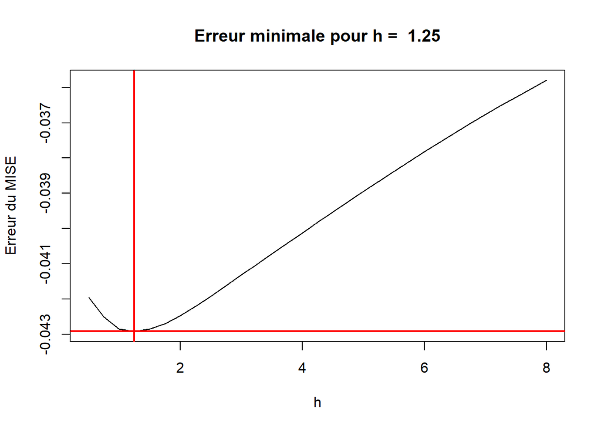